# Market_basket_analysis

Mohammed_Nihal

3/4/2020

# Loading librarys

```r
library(RMySQL)
library(DBI)
library(arules)
library(Matrix)
library(dplyr)
library(arulesViz)
library(ggplot2)
```

# Connecting to local data base

```r
mydb <-  dbConnect(RMySQL::MySQL(),
                  username = "root",
                  password = "rootpassword",
                  host = "127.0.0.1",
                  port = 3306,
                  dbname = "imarket_sql"
)
```

# Extracting dataset from the local data base

```r
rs = dbSendQuery(mydb, "select * from line_item")
line_item = fetch(rs, n=-1)
rs = dbSendQuery(mydb, "select * from orders")
orders=fetch(rs, n=-1)
rs = dbSendQuery(mydb, "select * from products")
products=fetch(rs, n=-1)
```

### * it is seen that there are some comma’s instead of decimal points in the data set

# Replace the comma’s with deimal points in unit price and total paid

```r
line_item$unit_price=as.numeric(gsub(",",".",line_item$unit_price))
orders$total_paid=as.numeric(gsub(",",".",orders$total_paid))
```

# Merge the line_item and order

```r
line_order=merge.data.frame(line_item,orders,by="id_order")
```

#### we have to do some data quality process in the data set

#### first of all we need to remove incompleted orders from the data.

#### then we need to check whether is there any diffrence in the prices

#### if so try to modify or filter the uneven changes

# Exclude not completed orders from the data set

```r
line_order=line_order %>%
  filter(state=='Completed')
```

# Find the difference between the prices in line_item and order

```r
data_diff =line_order %>%
  group_by(id_order) %>%
  summarise(sum_products=sum(unit_price*product_quantity), total_paid = mean(total_paid)) %>%
  mutate(differance =(sum_products - total_paid))
```

# Plot the graph of sum of product and total paid

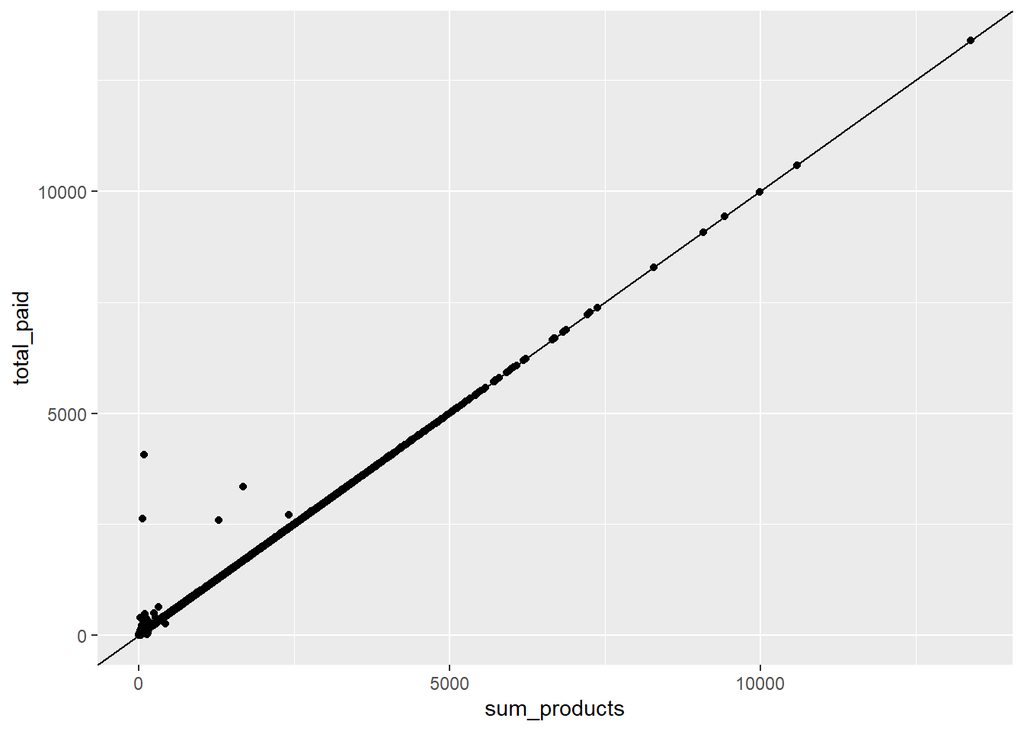

```r
data_diff %>% ggplot(aes(sum_products,total_paid))+geom_point()+geom_abline()
```

- remove the unexplainable differences

# Set some conditions to remove the unjustifiable diffrence

```r
select_id_order = data_diff %>% filter(differance<=sum_products*.7,differance>=-sum_products*.6)
```

# Plot the graph after filtration

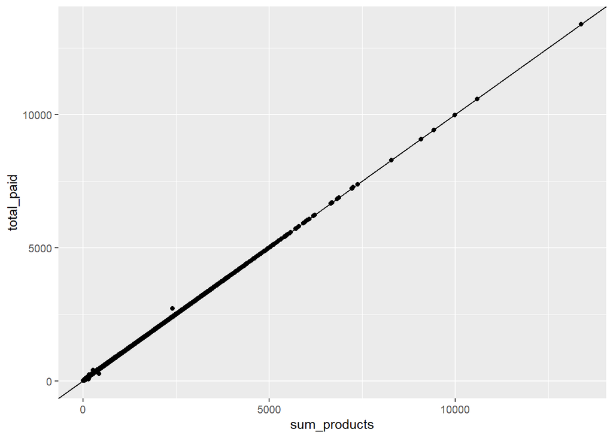

```r
select_id_order %>% ggplot(aes(sum_products,total_paid))+geom_point()+geom_abline()
```

# Merge product to line item

```r
line_product=merge(line_item,products,by="sku")
```

# Merge line product data set with the data set filtered previously

```r
filterd_data= merge(line_product,select_id_order,by='id_order')
filterd_data$price=as.numeric(filterd_data$price)
filterd_data=filterd_data %>% mutate(diffrence=abs(price-unit_price))
```

#### it is seen that there are some missing decimal points in the price table

# Fix the typing error in the price table

```r
data_error=filterd_data %>% select(id_order,name_en,sku,unit_price,price) %>%
  mutate(diffrence=abs(as.numeric(price)-unit_price)) %>% filter(diffrence>=unit_price,diffrence>=(as.numeric(price)*.95))
remaining=filterd_data %>% select(id_order,name_en,sku,unit_price,price) %>%
  mutate(diffrence=abs(as.numeric(price)-unit_price)) %>%
  filter(!(diffrence>=unit_price & diffrence>=(as.numeric(price)*.95)))
```

# Do a for loop to find the exact position of decimal point

```r
for (row in 1:nrow(data_error)) {
  price <- as.numeric(data_error$price)
  unit_price  <-as.numeric( data_error$unit_price)
  x<-nchar(as.character(as.integer(unit_price)))
  y<-nchar(as.character(as.integer(price)))
  data_error$price=(price/10^(y-x))
  data_error$diffrence=abs(price-unit_price)

}
```

# Add the modified price to the remaining data set

```r
filterd_data1=rbind(data_error,remaining)
```

# Remove the unjustifiable price difference

```r
data_diff2=filterd_data1 %>%select(id_order,name_en,unit_price,price)%>%
  mutate(diffrence=abs(as.numeric(price)-unit_price)) %>% filter(diffrence<=.75*as.numeric(price))
```

# Write a csv file

```r
write.csv(data_diff2,file ="filterd_dataset" )
```

# Read the dataset with read transaction

```r
modal_set<-read.transactions(file = "filterd_dataset",format = c("single"),
                               header=TRUE,sep = ",",cols = c("id_order","name_en"))
```

# Find the number of items per transaction

```r
table(size(modal_set))
```

```
##
##     1     2     3     4     5     6     7     8     9    10    11    13
## 35339  6962  2053   662   255    79    30    17    14     3     2     1
```

# Apply the apriori rule to the transaction

```r
RulesName <- apriori (modal_set, parameter = list(supp = 0.0004 , conf = 0.0002257014,minlen=2))
```

```
## Apriori
##
## Parameter specification:
##    confidence minval smax arem  aval originalSupport maxtime support minlen
##  0.0002257014    0.1    1 none FALSE            TRUE       5   4e-04      2
##  maxlen target   ext
##      10  rules FALSE
##
## Algorithmic control:
##  filter tree heap memopt load sort verbose
##     0.1 TRUE TRUE  FALSE TRUE    2    TRUE
##
## Absolute minimum support count: 18
##
## set item appearances ...[0 item(s)] done [0.00s].
## set transactions ...[5888 item(s), 45417 transaction(s)] done [0.18s].
## sorting and recoding items ... [738 item(s)] done [0.00s].
## creating transaction tree ... done [0.04s].
## checking subsets of size 1 2 done [0.01s].
## writing ... [18 rule(s)] done [0.00s].
## creating S4 object  ... done [0.02s].
```

# Select top ten rules and plot the graph

```r
top10subRules <- head(RulesName, n = 10, by = "confidence")

plot(top10subRules
     , method = "graph",  engine = "htmlwidget")
```

[interactive chart not shown]

# top recommendations from the analysis

### * OWC Kit of 5 tools for Mac and PC => Samsung 850 EVO SSD Disk 500GB

### * Smart Apple iPad Keyboard Case Keyboard Pro 10.5 <=> Apple Pencil

### * OEM 5W USB Power Adapter iPhone iPod and compatible Apple iPod <=> Apple Lightning Cable Connector to USB 1m White (OEM)

### * Spanish Keyboard Magic Apple Mac=> Apple Magic Mouse 2 <= Apple Magic Spanish Keyboard Keypad Bluetooth Mac

### * OWC In-line Digital Temperature Sensor Kit HDD iMac 2011 <=> AdaptaDrive NewerTech adapter 2.5 to 3.5 SATA